# Answer_HW5

# Ex 9

> For the same retail data, try an STL decomposition applied to the Box-Cox transformed series, followed by ETS on the seasonally adjusted data. How does that compare with your best previous forecasts on the test set?

```r
myts %>% window(end=c(2010,12)) %>%
  stlf(lambda=0) %>%
  accuracy(x=myts)
```

```
##                    ME   RMSE     MAE      MPE    MAPE    MASE     ACF1
## Training set -0.63743  8.131  5.8265 -0.29898  2.8602 0.36514 0.035926
## Test set     58.71961 73.704 58.7196 16.11340 16.1134 3.67992 0.393535
##              Theil's U
## Training set        NA
## Test set         1.368
```

That is worse (73.704 compared to 70.117).

# Ex 10

> For this exercise, use the quarterly UK passenger vehicle production data from 1977Q1–2005Q1 (data set `ukcars`).
> 1. Plot the data and describe the main features of the series.

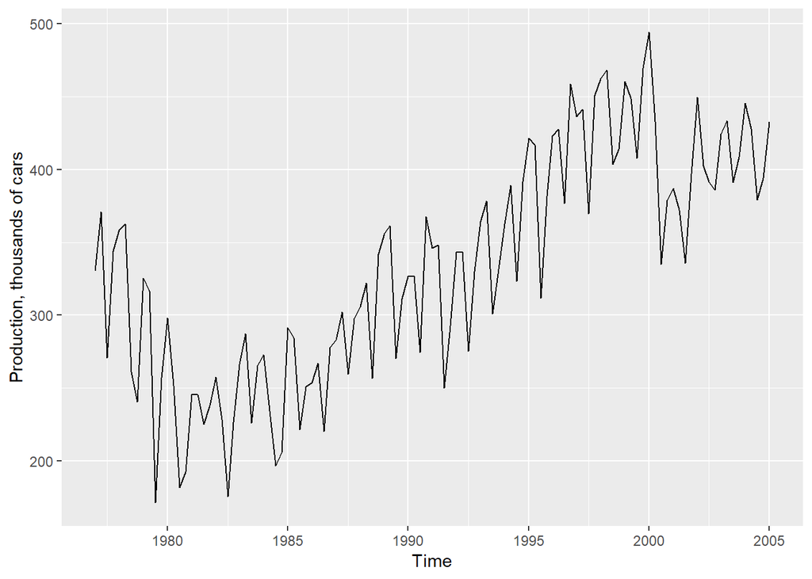

```r
autoplot(ukcars) + ylab("Production, thousands of cars")
```

- The data are seasonal with a nonlinear trend.
> 2. Decompose the series using STL and obtain the seasonally adjusted data.

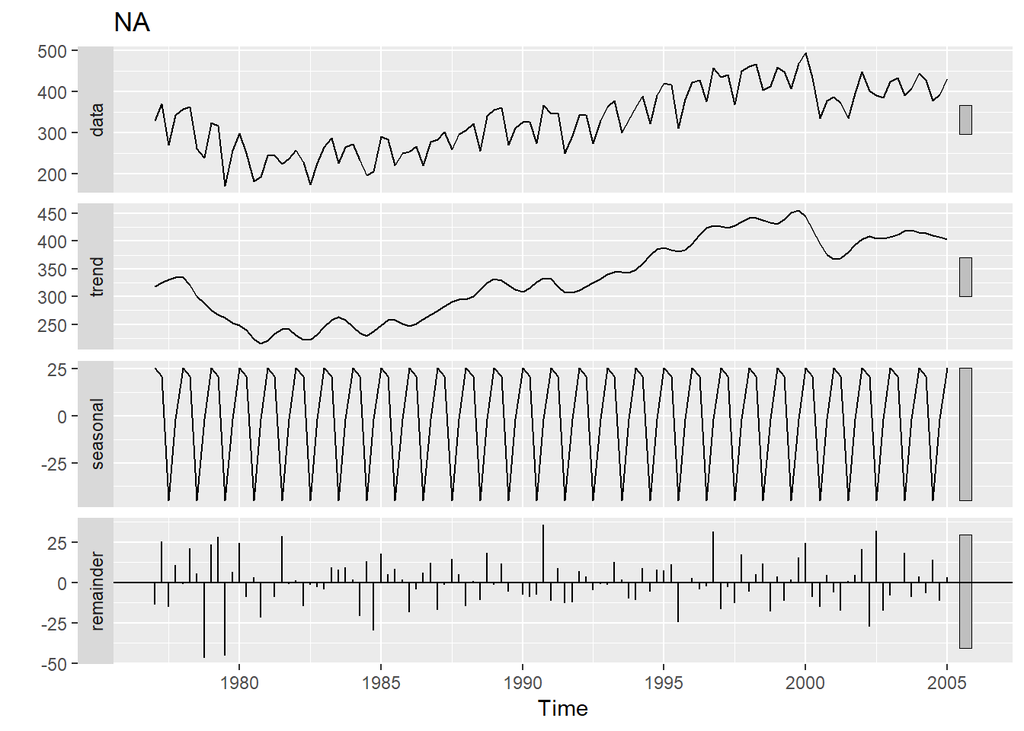

```r
stlFit <- stl(ukcars, s.window = "periodic")
autoplot(stlFit)
```

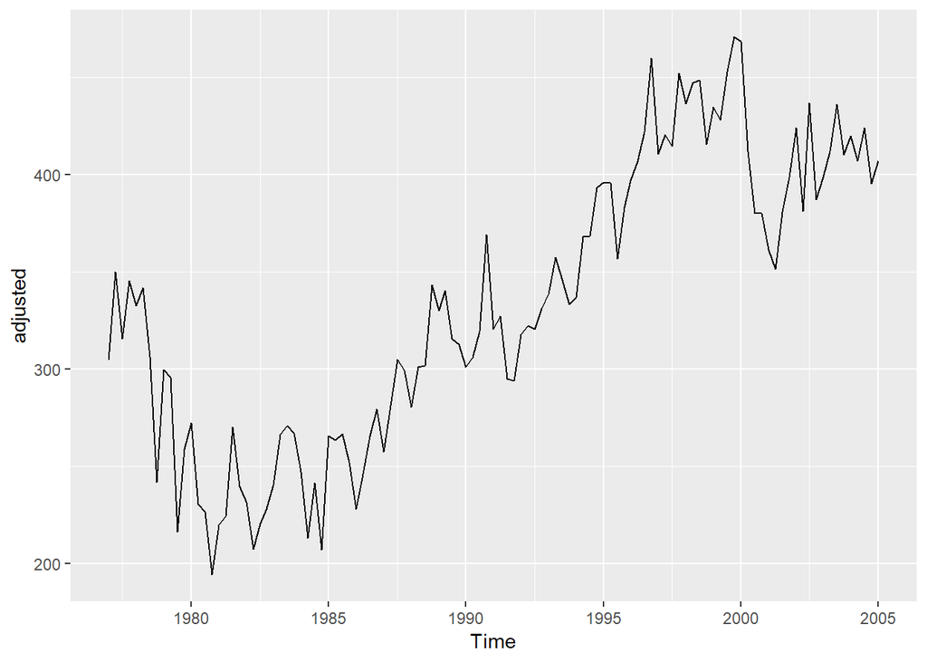

```r
adjusted <- seasadj(stlFit)
autoplot(adjusted)
```

> 3. Forecast the next two years of the series using an additive damped trend method applied to the seasonally adjusted data. (This can be done in one step using `stlf` with arguments `etsmodel="AAN", damped=TRUE`.)

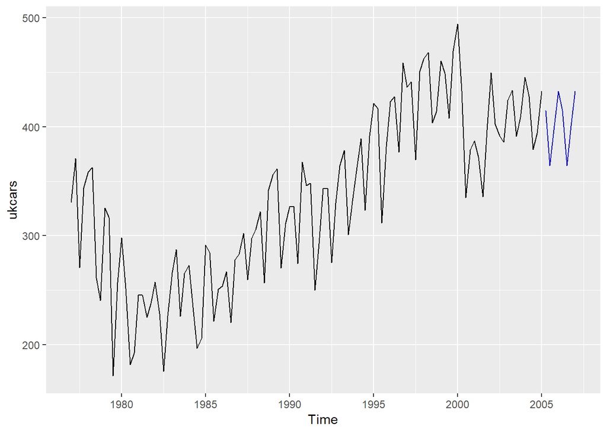

```r
fcastHoltDamp <- stlf(ukcars, etsmodel="AAN", damped=TRUE)
autoplot(ukcars) +
  autolayer(fcastHoltDamp, PI=FALSE)
```

> 4. Forecast the next two years of the series using Holtâ???Ts linear method applied to the seasonally adjusted data (as before but with `damped=FALSE`).

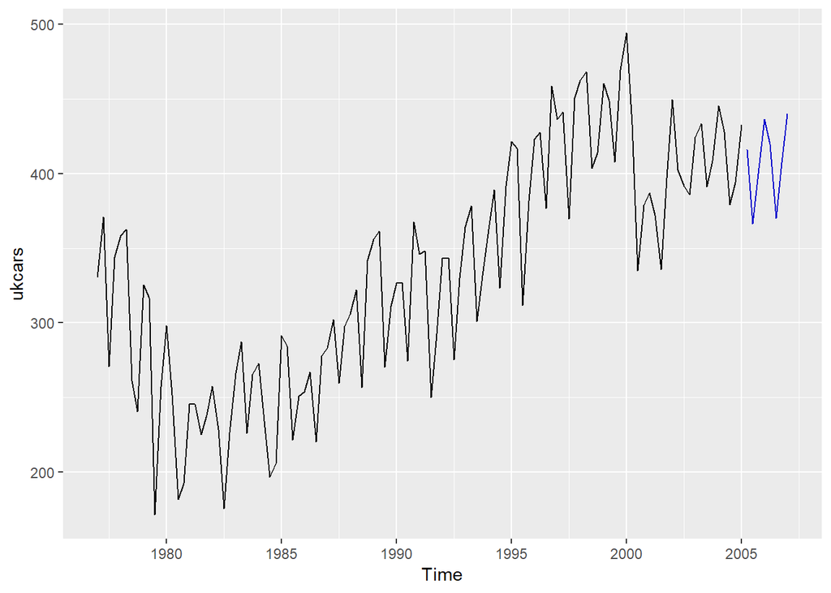

```r
fcastHolt <- stlf(ukcars, etsmodel="AAN", damped=FALSE)
autoplot(ukcars) +
  autolayer(fcastHolt, PI=FALSE)
```

> 5. Now use `ets()` to choose a seasonal model for the data.

```r
ukcarsets <- ets(ukcars)
```

> 6. Compare the RMSE of the ETS model with the RMSE of the models you obtained using STL decompositions. Which gives the better in-sample fits?

```r
accuracy(fcastHoltDamp)
```

```
##                  ME   RMSE   MAE     MPE   MAPE    MASE     ACF1
## Training set 1.5513 23.321 18.49 0.04122 6.0428 0.60258 0.022627
```

```r
accuracy(fcastHolt)
```

```
##                    ME   RMSE   MAE      MPE   MAPE    MASE     ACF1
## Training set -0.34127 23.295 18.16 -0.59708 5.9802 0.59184 0.021036
```

```r
accuracy(ukcarsets)
```

```
##                  ME   RMSE    MAE     MPE  MAPE    MASE     ACF1
## Training set 1.3139 25.232 20.179 -0.1571 6.629 0.65763 0.025733
```

Holt’s method does slightly better in-sample.

> 7. Compare the forecasts from the three approaches? Which seems most reasonable?

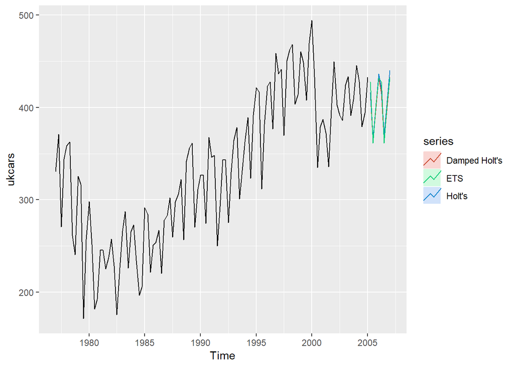

```r
autoplot(ukcars) +
  autolayer(fcastHoltDamp, PI=FALSE, series="Damped Holt's") +
  autolayer(fcastHolt, PI=FALSE, series="Holt's") +
  autolayer(forecast(ukcarsets), PI=FALSE, series="ETS")
```

The forecasts are almost identical. So I’ll use the Holt’s method which has smallest RMSE.

> 8. Check the residuals of your preferred model.

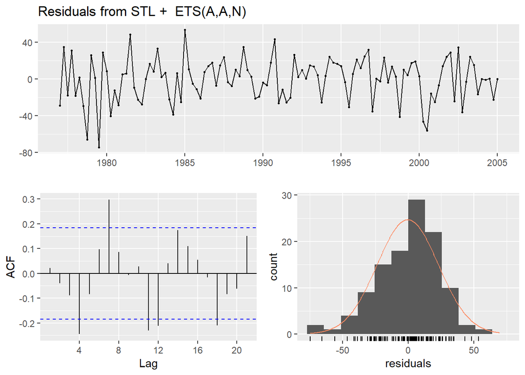

```
##
##  Ljung-Box test
##
## data:  Residuals from STL +  ETS(A,A,N)
## Q* = 22.1, df = 4, p-value = 0.00019
##
## Model df: 4.   Total lags used: 8
```

```r
checkresiduals(fcastHolt)
```

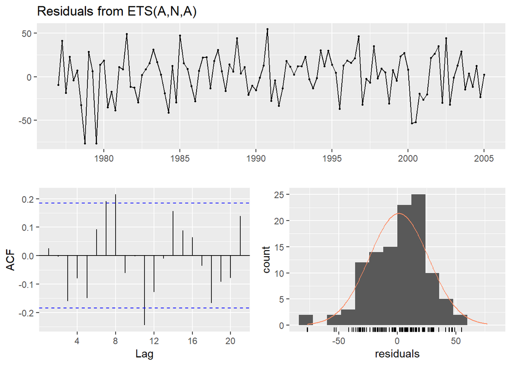

```
##
##  Ljung-Box test
##
## data:  Residuals from ETS(A,N,A)
## Q* = 18.3, df = 3, p-value = 0.00038
##
## Model df: 6.   Total lags used: 9
```

```r
checkresiduals(ukcarsets)
```

I’d probably go with the ETS model here due to its slightly better residual properties.

# Ex 11

> For this exercise, use the monthly Australian short-term overseas visitors data, May 1985–April 2005. (Data set: `visitors`.)
> 1. Make a time plot of your data and describe the main features of the series.

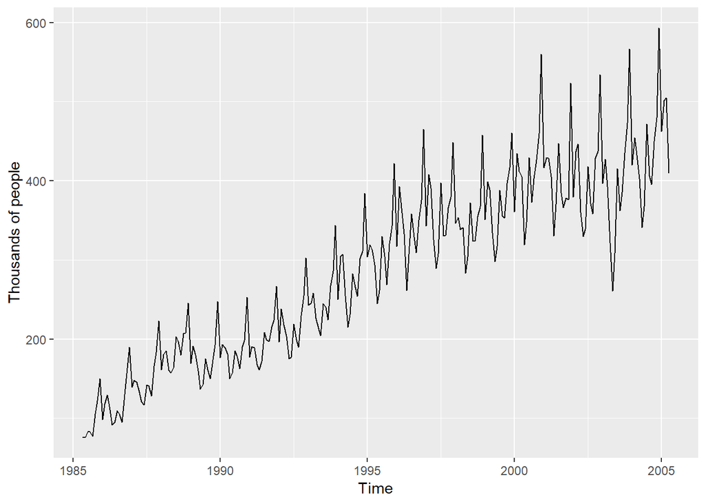

```r
autoplot(visitors) + ylab("Thousands of people")
```

- The data has upward trend.
- The data has seasonal pattern which increases in size approximately proportionally to the average number of people who arrive per year. Therefore, the data has multiplicative seasonality.
> 2. Split your data into a training set and a test set comprising the last two years of available data. Forecast the test set using Holt-Wintersâ???T multiplicative method.

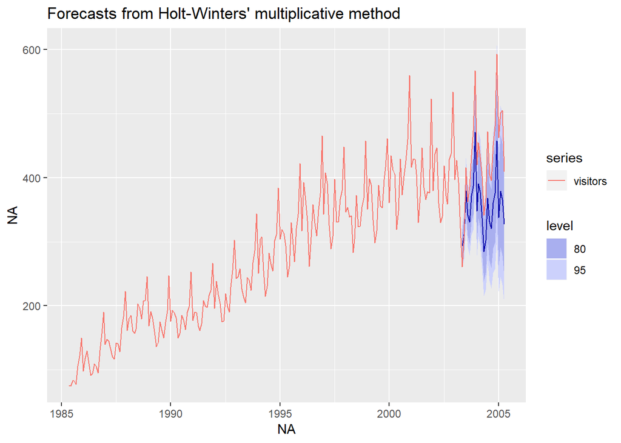

```r
train <- window(visitors, end=end(visitors)-c(2,0))
fcast <- hw(train, h=24, seasonal="multiplicative")
autoplot(fcast) +
  autolayer(visitors)
```

> 3. Why is multiplicative seasonality necessary here?

The multiplicative seasonality is important in this example because seasonal pattern increases in size proportionally to the level of the trend.

> 4. Forecast the two-year test set using each of the following methods:
>    1. an ETS model;
>    2. an additive ETS model applied to a Box-Cox transformed series;
>    3. a seasonal naÃ¯ve method;
>    4. an STL decomposition applied to the Box-Cox transformed data followed by an ETS model applied to the seasonally adjusted (transformed) data.

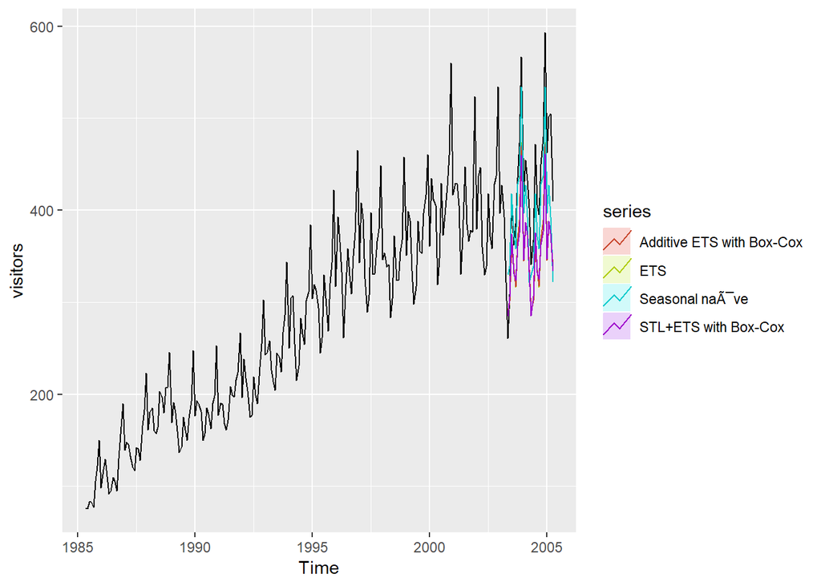

```r
f1 <- forecast(ets(train))
f2 <- forecast(ets(train, lambda=0))
f3 <- snaive(train)
f4 <- stlf(train, lambda=0)
autoplot(visitors) +
  autolayer(f1, PI=FALSE, series="ETS") +
  autolayer(f2, PI=FALSE, series="Additive ETS with Box-Cox") +
  autolayer(f3, PI=FALSE, series="Seasonal naÃ¯ve") +
  autolayer(f4, PI=FALSE, series="STL+ETS with Box-Cox")
```

> 5. Which method gives the best forecasts? Does it pass the residual tests?

```r
accuracy(f1,visitors)
```

```
##                    ME   RMSE    MAE      MPE    MAPE    MASE      ACF1
## Training set  0.76401 14.535 10.577  0.10482  3.9948 0.40542 -0.053112
## Test set     72.19927 80.231 74.553 15.92028 16.8224 2.85777  0.587170
##              Theil's U
## Training set        NA
## Test set        1.1273
```

```r
accuracy(f2,visitors)
```

```
##                    ME   RMSE    MAE      MPE    MAPE    MASE      ACF1
## Training set  0.90833 14.409 10.556  0.24231  3.9998 0.40463 -0.040151
## Test set     72.73026 80.669 75.035 16.04152 16.9249 2.87625  0.583589
##              Theil's U
## Training set        NA
## Test set        1.1346
```

```r
accuracy(f3,visitors)
```

```
##                  ME   RMSE    MAE    MPE    MAPE   MASE    ACF1 Theil's U
## Training set 17.294 31.156 26.088 7.1924 10.2860 1.0000 0.63277        NA
## Test set     32.871 50.301 42.246 6.6408  9.9626 1.6194 0.57254    0.6594
```

```r
accuracy(f4,visitors)
```

```
##                    ME   RMSE     MAE       MPE    MAPE    MASE      ACF1
## Training set  0.49277 13.082  9.2752  0.021424  3.4803 0.35554 -0.076999
## Test set     73.98213 82.362 75.9447 16.266959 17.0192 2.91112  0.655312
##              Theil's U
## Training set        NA
## Test set        1.1475
```

The best method is seasonal naÃ¯ve, although it fails the residuals tests:

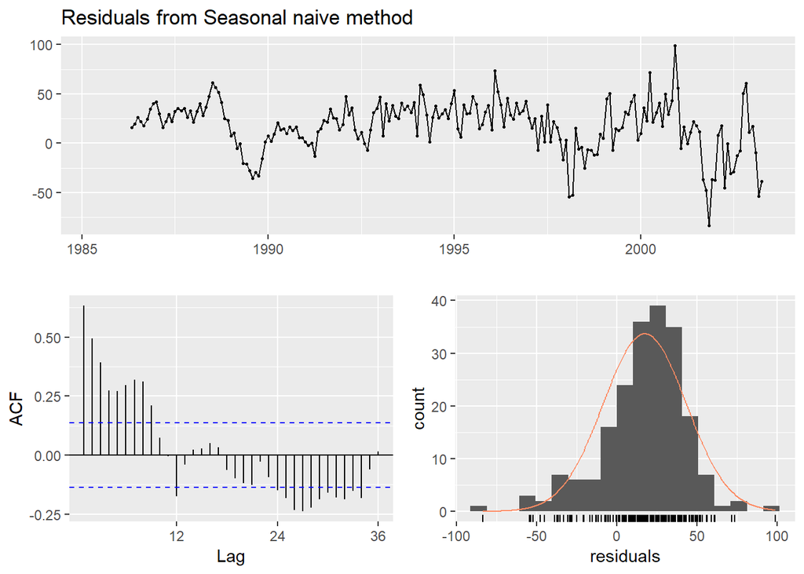

```
##
##  Ljung-Box test
##
## data:  Residuals from Seasonal naive method
## Q* = 295, df = 24, p-value <2e-16
##
## Model df: 0.   Total lags used: 24
```

```r
checkresiduals(f3)
```

> 6. Compare the same four methods using time series cross-validation with the `tsCV` function instead of using a training and test set. Do you come to the same conclusions?

```r
e <- matrix(NA,ncol=4,nrow=length(visitors))
f1 <- function(y,h){forecast(ets(y),h=h)}
e[,1] <- tsCV(visitors, f1)
f2 <- function(y,h){forecast(ets(y, lambda=0),h=h)}
e[,2] <- tsCV(visitors, f2)
e[,3] <- tsCV(visitors, snaive)
e[,4] <- tsCV(visitors, stlf, lambda=0)
colMeans(e^2, na.rm=TRUE)
```

```
## [1]  343.36  533.88 1074.97  294.13
```

Now the STLF method appears better (based on 1-step forecasts), even though it was worst on the test set earlier.

# Ex 12

The `fets()` function below returns ETS forecasts.

```r
fets <- function(y, h) {
  forecast(ets(y), h = h)
}
```

1. Apply `tsCV()` for a forecast horizon of $h=4$, for both ETS and seasonal naÃ¯ve methods to the `qcement` data, (Hint: use the newly created `fets()` and the existing `snaive()` functions as your forecast function arguments.)

```r
e1 <- tsCV(qcement, fets, h=4)
e2 <- tsCV(qcement, snaive, h=4)
```

2. Compute the MSE of the resulting 4-step-ahead errors. (Hint: make sure you remove missing values.) Why are there missing values? Comment on which forecasts are more accurate. Is this what you expected?

```r
colMeans(e1^2, na.rm=TRUE)
```

```
##       h=1       h=2       h=3       h=4
## 0.0069595 0.0105923 0.0141177 0.0184511
```

```r
colMeans(e2^2, na.rm=TRUE)
```

```
##      h=1      h=2      h=3      h=4
## 0.017792 0.017828 0.017964 0.018106
```

The ETS results are much better for the first 3 horizons, but the `snaive` results are slightly better for $h=4$. With a long series like this, I would expect ETS to do better as it should have no trouble estimating the parameters, and it will include trends if required.

# Ex 13

> Compare `ets`, `snaive` and `stlf` on the following six time series. For `stlf`, you might need to use a Box-Cox transformation. Use a test set of three years to decide what gives the best forecasts. `ausbeer`, `bricksq`, `dole`, `a10`, `h02`, `usmelec`.

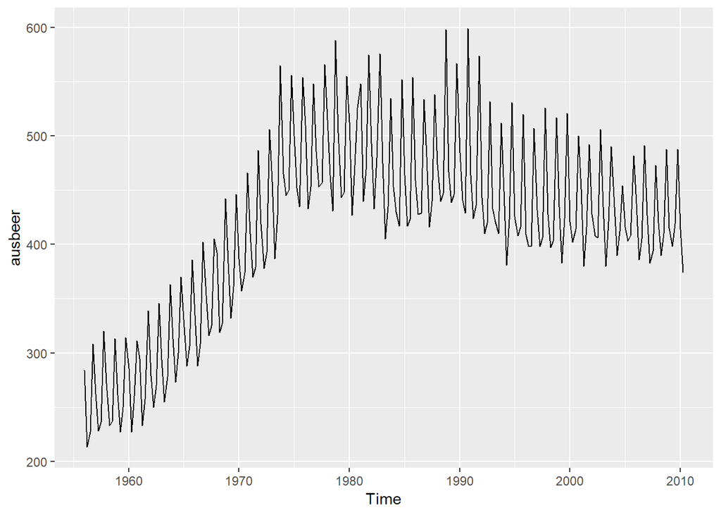

```r
autoplot(ausbeer)
```

A Box-Cox transformation does not seem to be required for this series.

```r
train <- window(ausbeer, end=end(ausbeer)-c(3,0))
fc1 <- forecast(ets(train))
fc2 <- snaive(train)
fc3 <- stlf(train)
accuracy(fc1, ausbeer)
```

```
##                    ME    RMSE     MAE       MPE   MAPE    MASE      ACF1
## Training set -0.34661 15.7820 11.9800 -0.064073 2.8643 0.75671 -0.194228
## Test set     -0.57976  8.8393  8.2509 -0.106162 1.9677 0.52116  0.074261
##              Theil's U
## Training set        NA
## Test set       0.15694
```

```r
accuracy(fc2, ausbeer)
```

```
##                   ME   RMSE    MAE      MPE   MAPE    MASE       ACF1
## Training set  3.3366 19.670 15.832  0.90440 3.7714 1.00000 0.00096908
## Test set     -3.0000 10.874  9.750 -0.62339 2.3192 0.61585 0.06636156
##              Theil's U
## Training set        NA
## Test set       0.19757
```

```r
accuracy(fc3, ausbeer)
```

```
##                    ME    RMSE     MAE      MPE   MAPE    MASE      ACF1
## Training set  0.64492 13.7795 10.6415  0.16432 2.5526 0.67216 -0.146951
## Test set     -3.82948  9.4617  7.9709 -0.86682 1.9048 0.50348  0.030773
##              Theil's U
## Training set        NA
## Test set       0.15847
```

Here, `ets` does best (based on RMSE) over the three year training set.

The other series are handled similarly.

# Ex 14

> 1. Use `ets()` on some of these series: `bicoal`, `chicken`, `dole`, `usdeaths`, `lynx`, `ibmclose`, `eggs`.

>    Does it always give good forecasts?

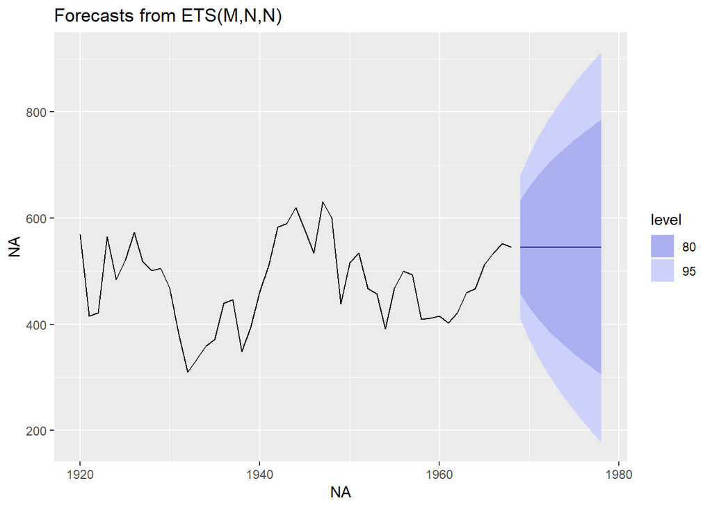

```r
bicoal %>% ets %>% forecast %>% autoplot
```

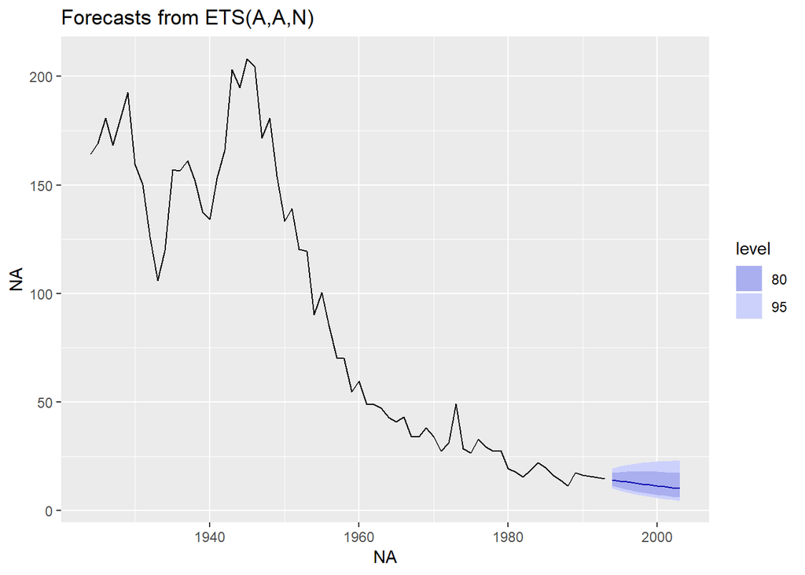

```r
chicken %>% ets(lambda=0) %>% forecast %>% autoplot
```

I’ve used a log transformation here to prevent the forecast intervals going negative

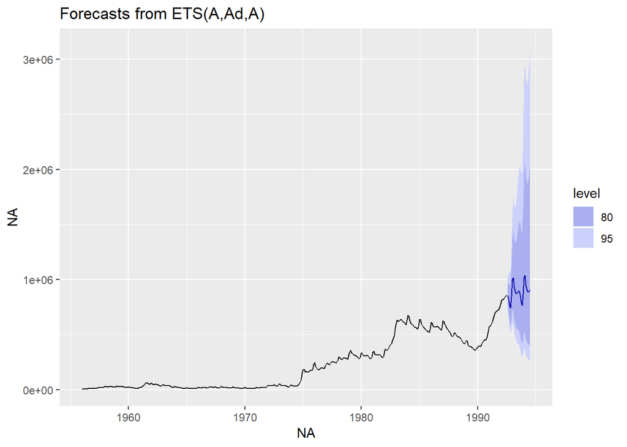

```r
dole %>% ets(lambda=0) %>% forecast %>% autoplot
```

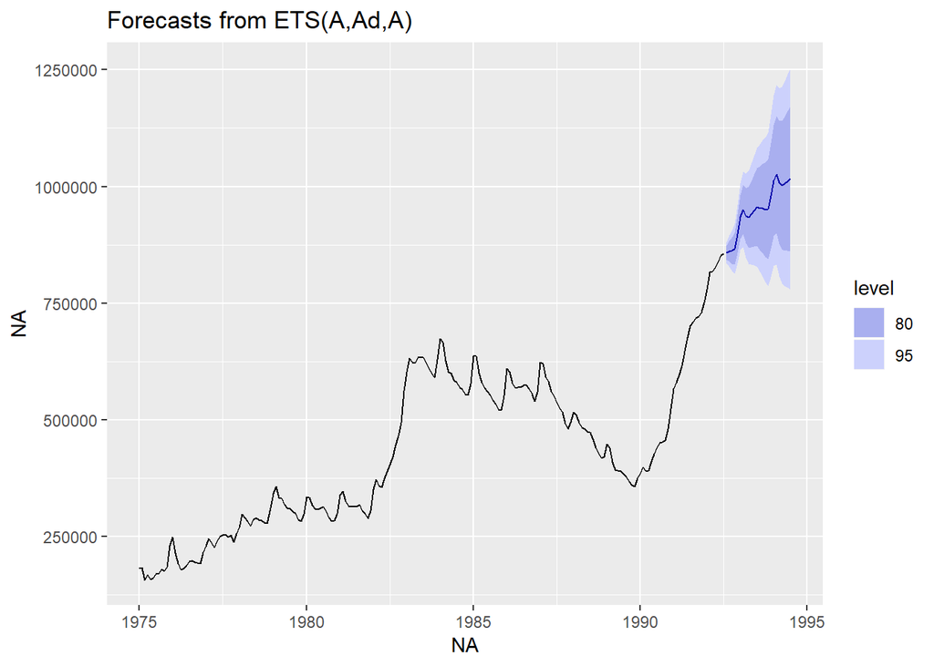

```r
dole %>% window(start=1975) %>% ets %>% forecast %>% autoplot
```

That looks a little more reasonable, although now the intervals are probably too narrow.

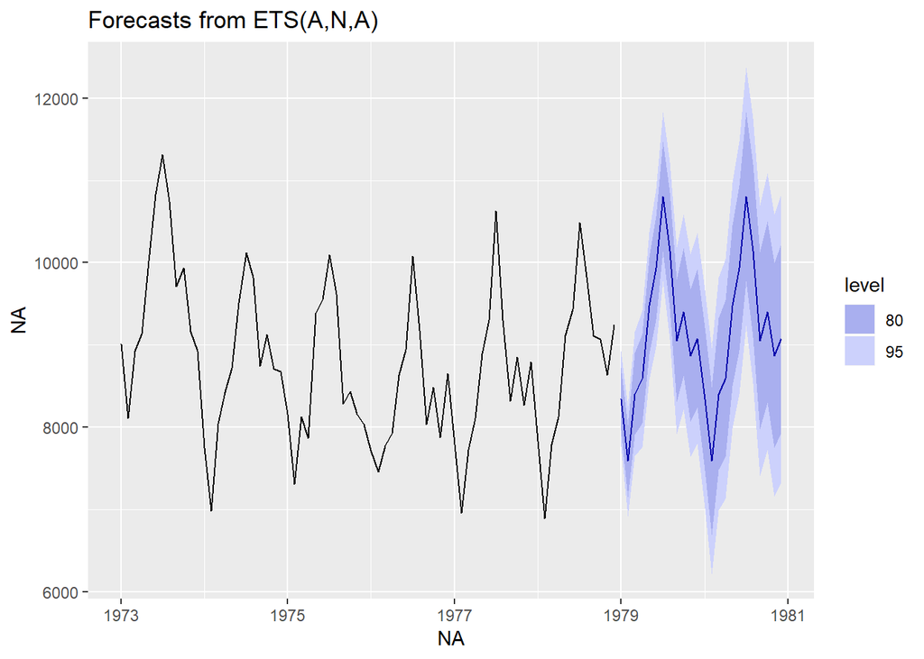

```r
usdeaths %>% ets %>% forecast %>% autoplot
```

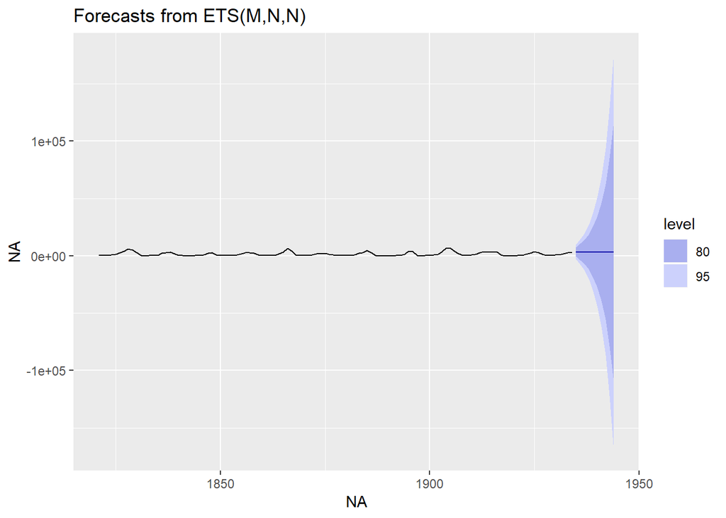

```r
lynx %>% ets %>% forecast %>% autoplot
```

Here the cyclic behaviour of the lynx data is completely lost. ETS models are not designed to handle cyclic data, so there is nothing that can be done to improve this.

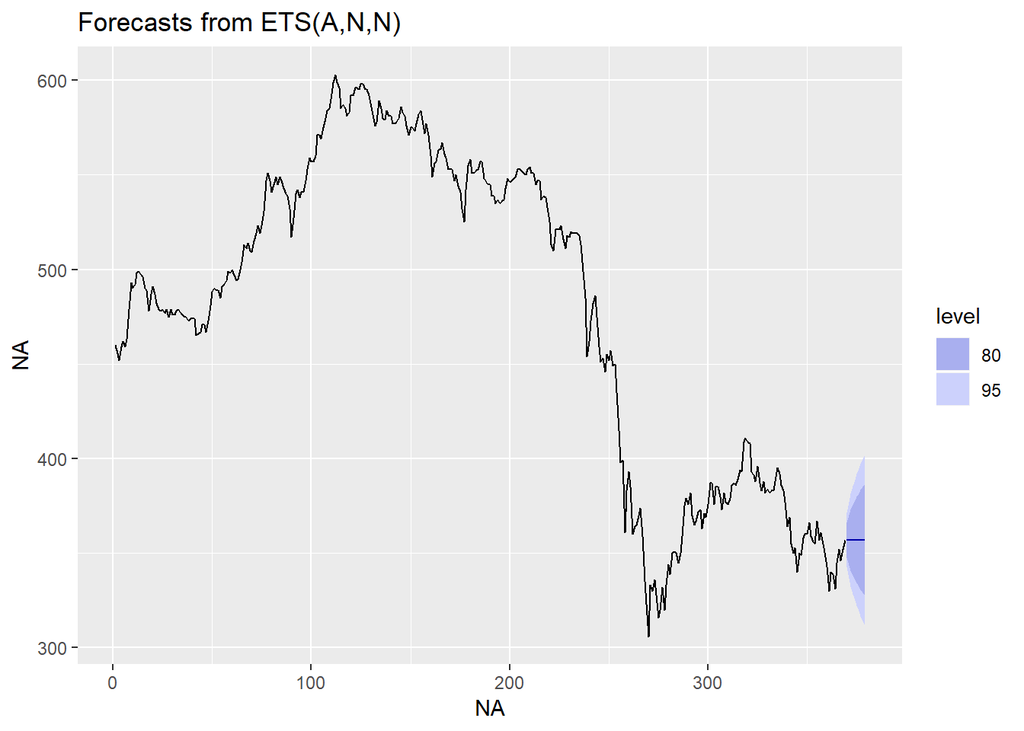

```r
ibmclose %>% ets %>% forecast %>% autoplot
```

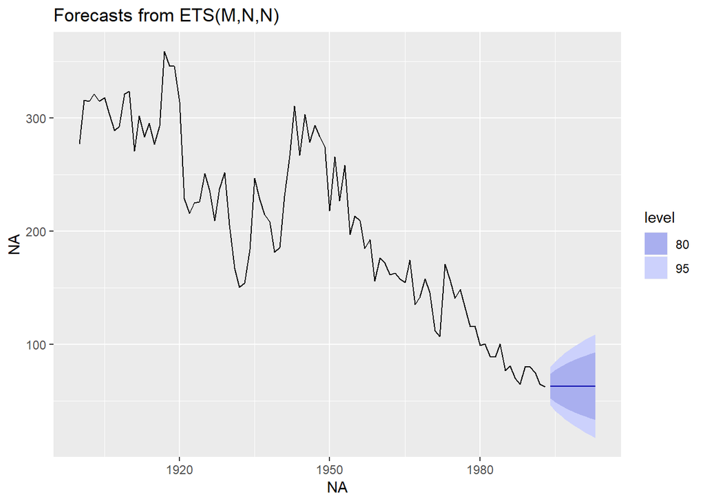

```r
eggs %>% ets %>% forecast %>% autoplot
```

> 2. Find an example where it does not work well. Can you figure out why?

See comments on lynx above.

# Ex 15

> Show that the point forecasts from an ETS(M,A,M) model are the same as those obtained using multiplicative Holt-Winters’ method.

Point forecasts from the multiplicative Holt-Winters’ method:

$$\hat{y}_{t+h|t} = (\ell_t + hb_t)s_{t-m+h_m^+}$$
An ETS(M,A,M) model is given by
$$\begin{align*}
y_t & = (\ell_{t-1}+b_{t-1})s_{t-m}(1+\varepsilon_t) \\
\ell_t & = (\ell_{t-1}+b_{t-1})(1+\alpha\varepsilon_t) \\
b_t & = b_{t-1} + \beta(\ell_{t-1}+b_{t-1})\varepsilon_t \\
s_t & = s_{t-m} (1+\gamma\varepsilon_t)
\end{align*}$$

So $y_{T+h}$ is given by

# Ex 16

> Show that the forecast variance for an ETS(A,N,N) model is given by

> $$\sigma^2\left[1+\alpha^2(h-1)\right].$$

An ETS(A,N,N) model is defined as
$$\begin{align*}
y_t & = \ell_{t-1} + \varepsilon_{t} \\
\ell_{t} & = \ell_{t-1} + \alpha\varepsilon_{t},
\end{align*}$$
where $\varepsilon_t \sim \text{N}(0,\sigma^2)$, and $h$-step forecasts are given by
$$\hat{y}_{T+h|T} = \ell_T.$$
So
$$\begin{align*}
y_{T+h} & = \ell_{T+h-1} + \varepsilon_{T+h} \\
& = \ell_{T+h-2} + \alpha \varepsilon_{T+h-1} + \varepsilon_{T+h} \\
& = \ell_{T+h-3} + \alpha \varepsilon_{T+h-2} + \alpha \varepsilon_{T+h-1} + \varepsilon_{T+h} \\
& \dots \\
& = \ell_{T} + \alpha \sum_{j=1}^{h-1} \varepsilon_{T+h-j} + \varepsilon_{T+h}.
\end{align*}$$
Therefore
$$\begin{align*}
\text{Var}(y_{T+h} | y_1,\dots,y_T) & = \alpha^2 \sum_{j=1}^{h-1} \sigma^2 + \sigma^2 \\
& = \sigma^2\left[ 1 + \alpha^2 (h-1)\right ].
\end{align*}$$

# Ex 17

> Write down the 95% prediction intervals for an ETS(A,N,N) model as a function of $\ell_T$, $\alpha$, $h$ and $\sigma$, assuming Gaussian errors.

Using previous result:

$$\ell_T \pm 1.96 \sigma \sqrt{ 1 + \alpha^2 (h-1)}$$

```